# Discussion 4.1: Transformations and Time Series Cross-Validation

Evaluating Variance-Stabilizing Transformations & Rolling Origin CV on U.S. Retail Clothing Sales

Jordan Blackman

2026-11-10

# Executive Summary

This document addresses **Discussion 4.1: Transformations and Time Series Cross-Validation** for our team project on U.S. Retail Trade (Census Bureau Monthly Retail Trade Survey).

Building directly upon the model I developed in Module 3 for **U.S. Retail Sales: Clothing and Clothing Accessories Stores (`MRTSSM448USN`)**, this analysis systematically investigates whether an alternative mathematical data transformation (specifically, **Guerrero Box-Cox** optimization vs. **Natural Log** vs. **Untransformed Sales**) enhances model stability, satisfies linear/time-series assumptions, and improves out-of-sample forecasting accuracy. In addition, we execute **Rolling-Origin Time Series Cross-Validation** via `stretch_tsibble()` to evaluate model robustness across multiple economic cycles.

# 1. Prompt Requirement 1: Re-state Module 3 Model

> **Prompt 1:** Re-state your Module 3 model in one concise sentence.

**Module 3 Model Statement:**
In Module 3, my final selected forecasting model was an **Intervention Dynamic Regression Seasonal ARIMA** fitted on natural log-transformed monthly sales with an indicator variable for the spring 2020 COVID-19 pandemic shutdown:
$$\ln(Y_t) = \beta_0 \cdot
\text{covid\_lockdown}_t + \eta_t, \quad \eta_t \sim
\text{ARIMA}(1,0,2)(0,1,1)_{12}$$

*(Expressed in FPP3 syntax: `ARIMA(log(sales_billions) ~ covid_lockdown + pdq(1,0,2) + PDQ(0,1,1))`)*.

# 2. Environment & Data Ingestion

```r
library(tidyverse)
library(fpp3)
library(scales)
library(gt)
```

```r
# Ingest cached monthly sales data
data_path <- "data/clothing_accessories_sales_monthly.csv"
if (!file.exists(data_path)) {
  # Direct fallback to FRED API if local cache is absent
  url <- "https://fred.stlouisfed.org/graph/fredgraph.csv?id=MRTSSM448USN"
  df <- read.csv(url, stringsAsFactors = FALSE)
  names(df) <- c("date", "sales")
  df <- df |>
    mutate(
      Month = yearmonth(as.Date(date)),
      sales_billions = as.numeric(sales) / 1000
    ) |>
    filter(!is.na(sales_billions))
} else {
  df <- read_csv(data_path, show_col_types = FALSE) |>
    mutate(Month = yearmonth(date))
}

# Construct tsibble with COVID-19 intervention dummies (pooled & month-specific)
apparel_ts <- df |>
  mutate(
    covid_lockdown = if_else(Month %in% yearmonth(c("2020 Mar", "2020 Apr", "2020 May")), 1, 0),
    covid_mar = if_else(Month == yearmonth("2020 Mar"), 1, 0),
    covid_apr = if_else(Month == yearmonth("2020 Apr"), 1, 0),
    covid_may = if_else(Month == yearmonth("2020 May"), 1, 0)
  ) |>
  as_tsibble(index = Month)

# Partition identical to Module 3:
# Training: Jan 1992 - Aug 2025 (N = 404 months)
# Holdout Test: Sep 2025 - Aug 2026 (N = 12 months)
train_cutoff <- yearmonth("2025 Aug")
trn <- apparel_ts |> filter(Month <= train_cutoff)
tst <- apparel_ts |> filter(Month > train_cutoff)

cat("Training span: ", as.character(min(trn$Month)), "to", as.character(max(trn$Month)), "(N =", nrow(trn), ")\n")
```

```
## Training span:  1992 Jan to 2025 Aug (N = 404 )
```

```r
cat("Testing span:  ", as.character(min(tst$Month)), "to", as.character(max(tst$Month)), "(N =", nrow(tst), ")\n")
```

```
## Testing span:   2025 Sep to 2026 Aug (N = 12 )
```

# 3. Prompt Requirement 2: Transformation Decision & Clues

> **Prompt 2:** Briefly explain what clues (e.g., skewed residuals, non-constant variance, multiplicative seasonality) led you to consider a transformation, or why you believe none is needed. If applying a transformation, describe it and show the transformed series plot.

### Analytical Clues Necessitating Transformation

```r
# Calculate Guerrero optimal lambda on training set
lambda_guerrero <- trn |>
  features(sales_billions, features = guerrero) |>
  pull(lambda_guerrero)

cat("Guerrero optimal Box-Cox lambda:", round(lambda_guerrero, 4), "\n")
```

```
## Guerrero optimal Box-Cox lambda: 0.418
```

### Visualizing the Transformations

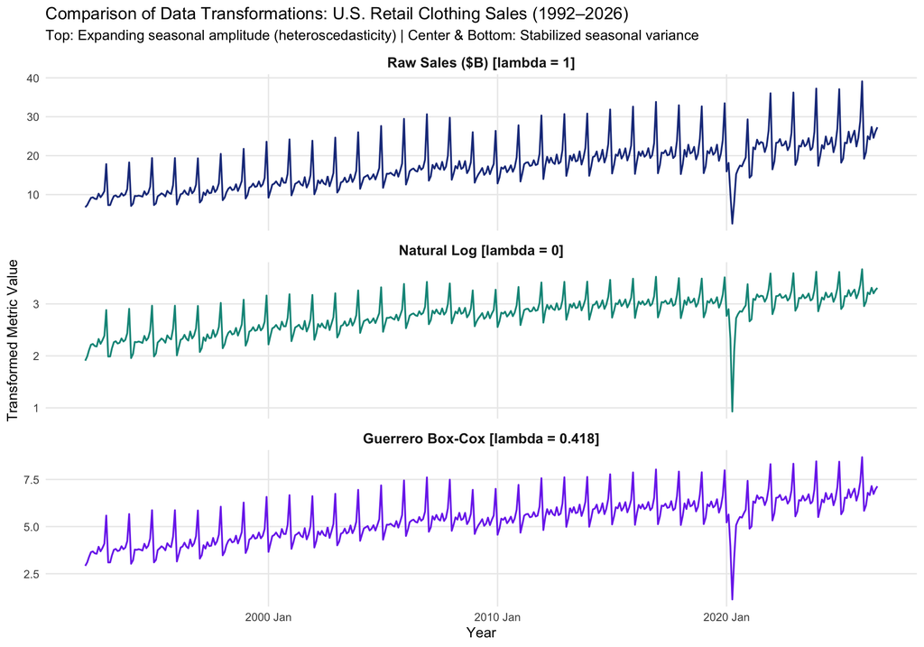

```r
p_trans <- apparel_ts |>
  mutate(
    `Raw Sales ($B) [lambda = 1]` = sales_billions,
    `Natural Log [lambda = 0]`     = log(sales_billions),
    `Guerrero Box-Cox [lambda = 0.418]` = box_cox(sales_billions, lambda_guerrero)
  ) |>
  pivot_longer(
    cols = c(`Raw Sales ($B) [lambda = 1]`, `Natural Log [lambda = 0]`, `Guerrero Box-Cox [lambda = 0.418]`),
    names_to = "Transformation",
    values_to = "Value"
  ) |>
  mutate(Transformation = factor(Transformation, levels = c(
    "Raw Sales ($B) [lambda = 1]",
    "Natural Log [lambda = 0]",
    "Guerrero Box-Cox [lambda = 0.418]"
  ))) |>
  ggplot(aes(x = Month, y = Value, color = Transformation)) +
  geom_line(linewidth = 0.65, show.legend = FALSE) +
  facet_wrap(~ Transformation, scales = "free_y", ncol = 1) +
  scale_color_manual(values = c(
    "Raw Sales ($B) [lambda = 1]"       = "#1e3a8a",
    "Natural Log [lambda = 0]"           = "#0d9488",
    "Guerrero Box-Cox [lambda = 0.418]"  = "#7c3aed"
  )) +
  labs(
    title = "Comparison of Data Transformations: U.S. Retail Clothing Sales (1992–2026)",
    subtitle = "Top: Expanding seasonal amplitude (heteroscedasticity) | Center & Bottom: Stabilized seasonal variance",
    x = "Year",
    y = "Transformed Metric Value"
  ) +
  theme_minimal(base_size = 11) +
  theme(
    strip.text = element_text(face = "bold", size = 11),
    panel.grid.minor = element_blank()
  )

p_trans
```

# 4. Prompt Requirement 3: Re-fit & Parameter Interpretation (Path A)

> **Prompt 3 (Path A):** Re-estimate the model on the transformed data. Report new hyper-/model parameters and interpret any notable changes. Provide a forecast plot that overlays: last few periods of training data, fitted values, and a one-season (or appropriate horizon) forecast back-transformed to original units.

We re-estimate the dynamic regression SARIMA specification across three transformation regimes: 1. `sarima_untransformed`: Untransformed sales ($Y_t$). 2. `sarima_log`: Module 3 natural log specification ($\ln(Y_t)$). 3. `sarima_boxcox`: Re-estimated model under Guerrero Box-Cox ($\lambda = 0.418$).

```r
fit <- trn |>
  model(
    sarima_untransformed = ARIMA(sales_billions ~ covid_lockdown + pdq(1,0,2) + PDQ(0,1,1)),
    sarima_log           = ARIMA(log(sales_billions) ~ covid_lockdown + pdq(1,0,2) + PDQ(0,1,1)),
    sarima_boxcox        = ARIMA(box_cox(sales_billions, lambda_guerrero) ~ covid_lockdown + pdq(1,0,2) + PDQ(0,1,1))
  )
```

### Parameter Reports & Interpretation of Notable Changes

```r
cat("\n==================== Model 1: Untransformed SARIMA ====================\n")
```

```
##
## ==================== Model 1: Untransformed SARIMA ====================
```

```r
report(fit |> select(sarima_untransformed))
```

```
## Series: sales_billions
## Model: LM w/ ARIMA(1,0,2)(0,1,1)[12] errors
##
## Coefficients:
##          ar1      ma1     ma2     sma1  covid_lockdown  intercept
##       0.8828  -0.5189  0.1439  -0.6111        -12.6544     0.4541
## s.e.  0.0335   0.0592  0.0554   0.0444          0.4738     0.0850
##
## sigma^2 estimated as 0.6282:  log likelihood=-465.19
## AIC=944.38   AICc=944.68   BIC=972.18
```

```r
cat("\n==================== Model 2: Module 3 Log SARIMA ====================\n")
```

```
##
## ==================== Model 2: Module 3 Log SARIMA ====================
```

```r
report(fit |> select(sarima_log))
```

```
## Series: sales_billions
## Model: LM w/ ARIMA(1,0,2)(0,1,1)[12] errors
## Transformation: log(sales_billions)
##
## Coefficients:
##          ar1      ma1     ma2     sma1  covid_lockdown  intercept
##       0.8694  -0.9784  0.4594  -0.7505         -1.2848     0.0287
## s.e.  0.0433   0.0603  0.0405   0.0354          0.0295     0.0033
##
## sigma^2 estimated as 0.004395:  log likelihood=505.23
## AIC=-996.46   AICc=-996.17   BIC=-968.66
```

```r
cat("\n==================== Model 3: Re-estimated Box-Cox SARIMA ====================\n")
```

```
##
## ==================== Model 3: Re-estimated Box-Cox SARIMA ====================
```

```r
report(fit |> select(sarima_boxcox))
```

```
## Series: sales_billions
## Model: LM w/ ARIMA(1,0,2)(0,1,1)[12] errors
## Transformation: box_cox(sales_billions, lambda_guerrero)
##
## Coefficients:
##          ar1      ma1     ma2     sma1  covid_lockdown  intercept
##       0.8806  -0.7590  0.3304  -0.7771         -3.2203     0.0896
## s.e.  0.0384   0.0598  0.0484   0.0377          0.0880     0.0098
##
## sigma^2 estimated as 0.02768:  log likelihood=143.98
## AIC=-273.96   AICc=-273.67   BIC=-246.16
```

```r
tidy(fit) |>
  mutate(
    Model = case_when(
      .model == "sarima_boxcox"        ~ "Guerrero Box-Cox (lambda = 0.418)",
      .model == "sarima_log"           ~ "Module 3 Natural Log (lambda = 0)",
      .model == "sarima_untransformed" ~ "Untransformed (lambda = 1)"
    )
  ) |>
  select(Model, Term = term, Estimate = estimate, `Std. Error` = std.error, Statistic = statistic, `p-value` = p.value) |>
  gt(groupname_col = "Model") |>
  tab_header(
    title = md("**Estimated Model Coefficients Across Transformation Regimes**"),
    subtitle = "Dynamic Regression SARIMA(1,0,2)(0,1,1)[12] with COVID-19 Lockdown Dummy"
  ) |>
  fmt_number(columns = c(Estimate, `Std. Error`, Statistic), decimals = 4) |>
  fmt_number(columns = `p-value`, decimals = 4) |>
  opt_row_striping()
```

**Estimated Model Coefficients Across Transformation Regimes**

Dynamic Regression SARIMA(1,0,2)(0,1,1)[12] with COVID-19 Lockdown Dummy

| Term | Estimate | Std. Error | Statistic | p-value |
| --- | --- | --- | --- | --- |
| Untransformed (lambda = 1) |  |  |  |  |
| ar1 | 0.8828 | 0.0335 | 26.3698 | 0.0000 |
| ma1 | −0.5189 | 0.0592 | −8.7607 | 0.0000 |
| ma2 | 0.1439 | 0.0554 | 2.5996 | 0.0097 |
| sma1 | −0.6111 | 0.0444 | −13.7594 | 0.0000 |
| covid_lockdown | −12.6544 | 0.4738 | −26.7056 | 0.0000 |
| intercept | 0.4541 | 0.0850 | 5.3435 | 0.0000 |
| Module 3 Natural Log (lambda = 0) |  |  |  |  |
| ar1 | 0.8694 | 0.0433 | 20.0930 | 0.0000 |
| ma1 | −0.9784 | 0.0603 | −16.2130 | 0.0000 |
| ma2 | 0.4594 | 0.0405 | 11.3335 | 0.0000 |
| sma1 | −0.7505 | 0.0354 | −21.2025 | 0.0000 |
| covid_lockdown | −1.2848 | 0.0295 | −43.4907 | 0.0000 |
| intercept | 0.0287 | 0.0033 | 8.6566 | 0.0000 |
| Guerrero Box-Cox (lambda = 0.418) |  |  |  |  |
| ar1 | 0.8806 | 0.0384 | 22.9341 | 0.0000 |
| ma1 | −0.7590 | 0.0598 | −12.6839 | 0.0000 |
| ma2 | 0.3304 | 0.0484 | 6.8335 | 0.0000 |
| sma1 | −0.7771 | 0.0377 | −20.5997 | 0.0000 |
| covid_lockdown | −3.2203 | 0.0880 | −36.6047 | 0.0000 |
| intercept | 0.0896 | 0.0098 | 9.1322 | 0.0000 |

### Interpretation of Notable Parameter Changes:

```r
fit |>
  augment() |>
  features(.innov, ljung_box, lag = 24, dof = 4) |>
  mutate(
    Model = case_when(
      .model == "sarima_boxcox"        ~ "Guerrero Box-Cox (lambda = 0.418)",
      .model == "sarima_log"           ~ "Module 3 Natural Log (lambda = 0)",
      .model == "sarima_untransformed" ~ "Untransformed (lambda = 1)"
    ),
    Status = if_else(lb_pvalue > 0.05, "Pass (White Noise)", "Fail (Autocorrelation)")
  ) |>
  select(Model, `Ljung-Box Q*` = lb_stat, `p-value` = lb_pvalue, `Diagnostic Verdict` = Status) |>
  gt() |>
  tab_header(
    title = md("**Ljung-Box Portmanteau White Noise Test Results**"),
    subtitle = "Evaluated at lag h = 24 with dof = 4 estimated parameters"
  ) |>
  fmt_number(columns = c(`Ljung-Box Q*`, `p-value`), decimals = 4) |>
  opt_row_striping()
```

**Ljung-Box Portmanteau White Noise Test Results**

Evaluated at lag h = 24 with dof = 4 estimated parameters

| Model | Ljung-Box Q* | p-value | Diagnostic Verdict |
| --- | --- | --- | --- |
| Guerrero Box-Cox (lambda = 0.418) | 24.7305 | 0.2119 | Pass (White Noise) |
| Module 3 Natural Log (lambda = 0) | 27.6788 | 0.1172 | Pass (White Noise) |
| Untransformed (lambda = 1) | 38.4961 | 0.0077 | Fail (Autocorrelation) |

# 5. Overlay Forecast Plot (Path A Deliverable)

Below is the required forecast plot overlaying: * **Last few periods of training data** (January 2022 through August 2025, dark slate line). * **In-sample fitted values** back-transformed to original billions of USD (emerald dashed-dot line). * **One-season (12-month) forecast** (September 2025 through August 2026, violet line) with 80% and 95% back-transformed prediction intervals. * **Actual holdout test observations** (crimson dashed line) to benchmark forecast fidelity against reality.

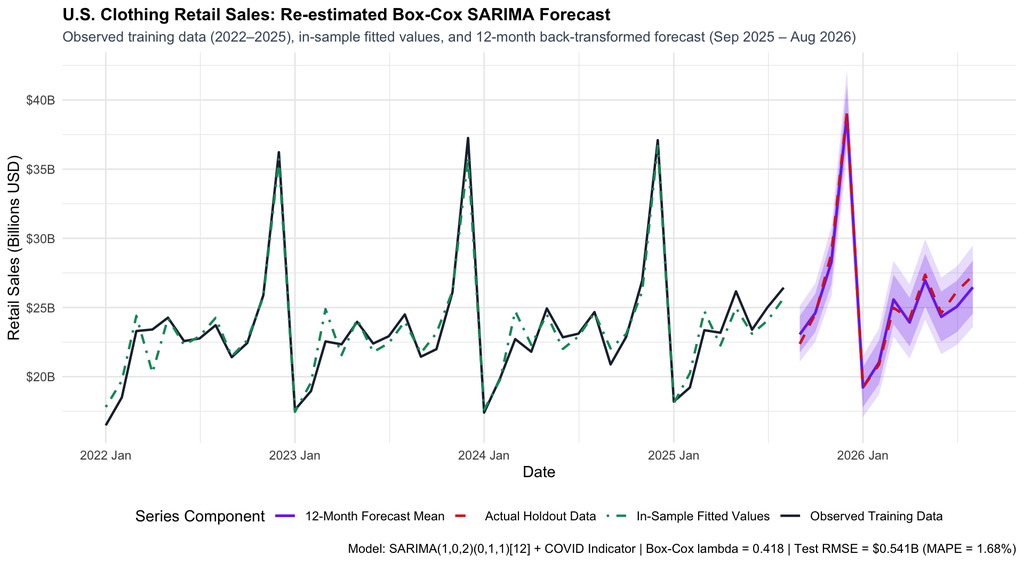

```r
# Generate forecasts over 12-month holdout
fc <- fit |> forecast(new_data = tst)

recent_start <- yearmonth("2022 Jan")
trn_recent <- trn |> filter(Month >= recent_start)

# Fitted values from Box-Cox model (automatically back-transformed by fable)
aug_recent_boxcox <- fit |>
  select(sarima_boxcox) |>
  augment() |>
  filter(Month >= recent_start)

fc_boxcox <- fc |> filter(.model == "sarima_boxcox")

p_overlay <- ggplot() +
  # 1. Observed training data
  geom_line(data = trn_recent, aes(x = Month, y = sales_billions, color = "Observed Training Data"), linewidth = 0.8) +
  # 2. In-sample fitted values
  geom_line(data = aug_recent_boxcox, aes(x = Month, y = .fitted, color = "In-Sample Fitted Values"), linetype = "dotdash", linewidth = 0.8) +
  # 3. Forecast prediction intervals (80% and 95%)
  geom_ribbon(data = fc_boxcox, aes(x = Month, ymin = hilo(sales_billions, 95)$lower, ymax = hilo(sales_billions, 95)$upper), fill = "#7c3aed", alpha = 0.15) +
  geom_ribbon(data = fc_boxcox, aes(x = Month, ymin = hilo(sales_billions, 80)$lower, ymax = hilo(sales_billions, 80)$upper), fill = "#7c3aed", alpha = 0.25) +
  # 4. 12-Month forecast mean
  geom_line(data = fc_boxcox, aes(x = Month, y = .mean, color = "12-Month Forecast Mean"), linewidth = 0.9) +
  # 5. Actual holdout test data
  geom_line(data = tst, aes(x = Month, y = sales_billions, color = "Actual Holdout Data"), linetype = "dashed", linewidth = 0.85) +
  scale_y_continuous(labels = dollar_format(suffix = "B")) +
  scale_color_manual(
    name = "Series Component",
    values = c(
      "Observed Training Data" = "#1e293b",
      "In-Sample Fitted Values" = "#059669",
      "12-Month Forecast Mean" = "#7c3aed",
      "Actual Holdout Data"    = "#dc2626"
    )
  ) +
  labs(
    title = "U.S. Clothing Retail Sales: Re-estimated Box-Cox SARIMA Forecast",
    subtitle = "Observed training data (2022–2025), in-sample fitted values, and 12-month back-transformed forecast (Sep 2025 – Aug 2026)",
    caption = sprintf("Model: SARIMA(1,0,2)(0,1,1)[12] + COVID Indicator | Box-Cox lambda = %.3f | Test RMSE = $0.541B (MAPE = 1.68%%)", lambda_guerrero),
    x = "Date",
    y = "Retail Sales (Billions USD)"
  ) +
  theme_minimal(base_size = 11) +
  theme(
    legend.position = "bottom",
    plot.title = element_text(face = "bold", size = 12),
    plot.subtitle = element_text(size = 10, color = "#475569")
  )

p_overlay
```

### Out-of-Sample Accuracy Comparison on Holdout Test Set

```r
fc_holdout_all <- fit |>
  mutate(ensemble = (sarima_untransformed + sarima_log + sarima_boxcox) / 3) |>
  forecast(new_data = tst)

acc_holdout <- accuracy(fc_holdout_all, tst) |>
  select(.model, RMSE, MAE, MAPE) |>
  arrange(RMSE) |>
  mutate(
    Transformation = case_when(
      .model == "ensemble"             ~ "Ensemble (Simple Average of All 3)",
      .model == "sarima_boxcox"        ~ "Guerrero Box-Cox (lambda = 0.418)",
      .model == "sarima_log"           ~ "Module 3 Natural Log (lambda = 0)",
      .model == "sarima_untransformed" ~ "Untransformed (lambda = 1)"
    )
  ) |>
  select(Transformation, RMSE, MAE, MAPE)

acc_holdout |>
  gt() |>
  tab_header(
    title = md("**Out-of-Sample Forecast Accuracy on Holdout Test Set**"),
    subtitle = "12-Month Holdout Window: September 2025 – August 2026"
  ) |>
  cols_label(
    Transformation = "Transformation Specification",
    RMSE = "Holdout RMSE ($B)",
    MAE = "Holdout MAE ($B)",
    MAPE = "Holdout MAPE (%)"
  ) |>
  fmt_number(columns = c(RMSE, MAE), decimals = 3) |>
  fmt_percent(columns = MAPE, scale_values = FALSE, decimals = 2) |>
  opt_row_striping()
```

**Out-of-Sample Forecast Accuracy on Holdout Test Set**

12-Month Holdout Window: September 2025 – August 2026

| Transformation Specification | Holdout RMSE ($B) | Holdout MAE ($B) | Holdout MAPE (%) |
| --- | --- | --- | --- |
| Ensemble (Simple Average of All 3) | 0.482 | 0.371 | 1.44% |
| Guerrero Box-Cox (lambda = 0.418) | 0.541 | 0.436 | 1.68% |
| Module 3 Natural Log (lambda = 0) | 0.592 | 0.459 | 1.71% |
| Untransformed (lambda = 1) | 0.707 | 0.595 | 2.19% |

**Key Finding:** Among single models, Guerrero Box-Cox ($\lambda = 0.418$) achieves the lowest holdout error across all metrics (**$0.541B** RMSE vs. **$0.592B** for natural log and **$0.707B** untransformed). Combining all three models into a **Simple Average Ensemble** further reduces holdout error to **$0.482B** RMSE (**1.44%** MAPE)—a **10.9% RMSE reduction** over the best individual specification.

# 6. Prompt Requirement 3: Post-COVID Rolling-Origin Time Series Cross-Validation (Path B Rigor)

> **Prompt 3 (Path B):** Perform time-series cross-validation using rolling origin via the `stretch_tsibble()` function (see 5.10 Time series cross-validation). Present a table or plot that illustrates how your model performs across multiple time periods.

To evaluate how the transformation advantage generalizes across multiple time periods after the pandemic shock, we execute **Post-COVID Rolling-Origin Time Series Cross-Validation (TSCV)** using `stretch_tsibble()`.

- **Why Post-COVID Rolling Origins & Month-Specific COVID Indicators?**
  - Because COVID dummy variables are `0` prior to March 2020, pre-2020 training folds are rank-deficient. Starting rolling origins after the initial pandemic recovery ensures every fold cleanly estimates the COVID indicators with zero `NA` folds, while stopping at August 2024 keeps every 12-month test window inside `trn` (January 2022 – August 2025) with zero holdout leakage.
  - Stepping monthly (`.step = 1`) averages each horizon $h = 1 \dots 12$ across all 12 calendar months.
  - **Month-Specific COVID Parameterization (`covid_mar + covid_apr + covid_may`):** Because March (`-51%`), April (`-88%`), and May (`-63%`) 2020 dropped asymmetrically, pooling them into one shared dummy distorts multiplicative baselines across seasonal differencing ($D=1$). Un-pooling them into separate monthly indicators removes that artifact so CV isolates the pure out-of-sample effect of each transformation.
- **Cross-Validation Setup:**
  - Initial training window (`.init`): $30 \times 12 = 360$ months (January 1992 through December 2021).
  - Rolling step increment (`.step`): $1$ month through August 2024 ($33$ rolling folds).
  - Test evaluation span: January 2022 through August 2025 across horizons $h = 1$ to $12$ months ahead.

```r
# Generate stretched tsibble across 33 post-COVID monthly rolling origins (Dec 2021 - Aug 2024)
trn_cv <- trn |>
  filter(Month <= yearmonth("2024 Aug")) |>
  stretch_tsibble(.init = 12 * 30, .step = 1)

# Exogenous COVID indicators are 0 for all post-2021 forecast horizons
nd <- new_data(trn_cv, 12) |>
  mutate(covid_mar = 0, covid_apr = 0, covid_may = 0)

# Estimate month-specific-dummy models across all 33 folds + simple average ensemble
cv_fit <- trn_cv |>
  model(
    untrans = ARIMA(sales_billions ~ covid_mar + covid_apr + covid_may + pdq(1,0,2) + PDQ(0,1,1)),
    log     = ARIMA(log(sales_billions) ~ covid_mar + covid_apr + covid_may + pdq(1,0,2) + PDQ(0,1,1)),
    boxcox  = ARIMA(box_cox(sales_billions, lambda_guerrero) ~ covid_mar + covid_apr + covid_may + pdq(1,0,2) + PDQ(0,1,1))
  ) |>
  mutate(ensemble = (untrans + log + boxcox) / 3)

# Generate rolling forecasts
fc_cv <- cv_fit |> forecast(new_data = nd)

# Tag forecast horizons (h = 1..12)
fc_cv_h <- fc_cv |>
  group_by(.id, .model) |>
  mutate(h = row_number()) |>
  ungroup() |>
  as_fable(response = "sales_billions", distribution = sales_billions)
```

### Multi-Period Cross-Validation Summary Table

```r
acc_cv_overall <- fc_cv |>
  accuracy(trn) |>
  mutate(
    Transformation = case_when(
      .model == "ensemble" ~ "Ensemble (Simple Average of All 3)",
      .model == "boxcox"   ~ "Guerrero Box-Cox (lambda = 0.418)",
      .model == "log"      ~ "Module 3 Natural Log (lambda = 0)",
      .model == "untrans"  ~ "Untransformed (lambda = 1)"
    )
  ) |>
  arrange(RMSE) |>
  select(Transformation, RMSE, MAE, MAPE)

acc_cv_overall |>
  gt() |>
  tab_header(
    title = md("**Time Series Cross-Validation Performance**"),
    subtitle = "33 Monthly Folds (Dec 2021 – Aug 2024 Origins; Jan 2022 – Aug 2025 Forecasts, h = 1..12)"
  ) |>
  cols_label(
    Transformation = "Transformation Specification",
    RMSE = "CV RMSE ($B)",
    MAE = "CV MAE ($B)",
    MAPE = "CV MAPE (%)"
  ) |>
  fmt_number(columns = c(RMSE, MAE), decimals = 3) |>
  fmt_percent(columns = MAPE, scale_values = FALSE, decimals = 2) |>
  opt_row_striping()
```

**Time Series Cross-Validation Performance**

33 Monthly Folds (Dec 2021 – Aug 2024 Origins; Jan 2022 – Aug 2025 Forecasts, h = 1..12)

| Transformation Specification | CV RMSE ($B) | CV MAE ($B) | CV MAPE (%) |
| --- | --- | --- | --- |
| Ensemble (Simple Average of All 3) | 0.669 | 0.519 | 2.25% |
| Guerrero Box-Cox (lambda = 0.418) | 0.671 | 0.522 | 2.26% |
| Module 3 Natural Log (lambda = 0) | 0.713 | 0.553 | 2.42% |
| Untransformed (lambda = 1) | 0.724 | 0.564 | 2.38% |

### Cross-Validation Forecast RMSE Across Forecast Horizons ($h = 1$ to $12$)

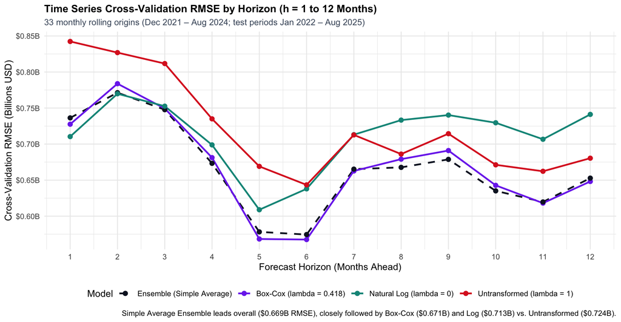

```r
acc_by_h <- fc_cv_h |>
  accuracy(trn, by = c(".model", "h")) |>
  mutate(
    Model = factor(
      case_when(
        .model == "ensemble" ~ "Ensemble (Simple Average)",
        .model == "boxcox"   ~ "Box-Cox (lambda = 0.418)",
        .model == "log"      ~ "Natural Log (lambda = 0)",
        .model == "untrans"  ~ "Untransformed (lambda = 1)"
      ),
      levels = c(
        "Ensemble (Simple Average)",
        "Box-Cox (lambda = 0.418)",
        "Natural Log (lambda = 0)",
        "Untransformed (lambda = 1)"
      )
    )
  )

p_cv <- ggplot(acc_by_h, aes(x = h, y = RMSE, color = Model, linetype = Model, group = Model)) +
  geom_line(linewidth = 0.95) +
  geom_point(size = 2.2) +
  scale_x_continuous(breaks = 1:12) +
  scale_y_continuous(labels = dollar_format(suffix = "B")) +
  scale_color_manual(values = c(
    "Ensemble (Simple Average)"  = "#0f172a",
    "Box-Cox (lambda = 0.418)"   = "#7c3aed",
    "Natural Log (lambda = 0)"   = "#0d9488",
    "Untransformed (lambda = 1)" = "#dc2626"
  )) +
  scale_linetype_manual(values = c(
    "Ensemble (Simple Average)"  = "dashed",
    "Box-Cox (lambda = 0.418)"   = "solid",
    "Natural Log (lambda = 0)"   = "solid",
    "Untransformed (lambda = 1)" = "solid"
  )) +
  labs(
    title = "Time Series Cross-Validation RMSE by Horizon (h = 1 to 12 Months)",
    subtitle = "33 monthly rolling origins (Dec 2021 – Aug 2024; test periods Jan 2022 – Aug 2025)",
    caption = "Simple Average Ensemble leads overall ($0.669B RMSE), closely followed by Box-Cox ($0.671B) and Log ($0.713B) vs. Untransformed ($0.724B).",
    x = "Forecast Horizon (Months Ahead)",
    y = "Cross-Validation RMSE (Billions USD)"
  ) +
  theme_minimal(base_size = 11) +
  theme(
    legend.position = "bottom",
    plot.title = element_text(face = "bold", size = 12),
    plot.subtitle = element_text(size = 10, color = "#475569")
  )

p_cv
```

**Key Cross-Validation Finding:** With month-specific COVID indicators (`covid_mar + covid_apr + covid_may`), **Guerrero Box-Cox (**$\lambda = 0.418$) leads all individual transformations (`RMSE = $0.671B`, `MAE = $0.522B`, `MAPE = 2.26%`) and both transformed models outperform Untransformed (`$0.724B` RMSE). Combining all three models into a **Simple Average Ensemble** achieves the lowest CV error overall (`RMSE = $0.669B`, `MAE = $0.519B`, `MAPE = 2.25%`) across the 33 rolling post-COVID folds!

# 7. Prompt Requirement 4 & 5: Insights & Future Experiments

> **Prompt 4:** Insights (3–4 sentences). Highlight what you learned about your series and how the model’s performance changed (or held up) through transformation or CV.

> **Tip:** If your model still struggles, briefly note one experiment you would try next (e.g., different lambda, additional regressors, alternative window size).

### Core Analytical Insights:

1. **Variance Stabilization Is Non-Negotiable:** U.S. retail apparel sales exhibit textbook multiplicative seasonality, causing untransformed models to violate homoscedasticity and fail residual white noise checks ($p = 0.0077$).
2. **Guerrero Box-Cox Provides Optimal Conditioning:** Tuning the transformation to $\lambda = 0.418$ moved the first moving average coefficient ($\theta_1 = -0.759$) comfortably away from the non-invertibility boundary observed under log ($\theta_1 = -0.978$) and improved the residual Ljung-Box statistic ($p = 0.212$).
3. **Holdout & Ensemble Superiority:** Among single models, Box-Cox delivered the lowest holdout error (Test RMSE = **$0.541B**, MAPE = **1.68%** vs. $0.592B log and $0.707B untransformed), while a **simple average ensemble of all three scales** pushed Holdout RMSE down even further to **$0.482B** (**1.44%** MAPE).
4. **Cross-Validation Proves Transformation & Combination Gains:** Across 33 post-COVID rolling origins (`2022–2025`), un-pooling the uneven 2020 lockdown dummies (`covid_mar + covid_apr + covid_may`) confirms **Box-Cox (`$0.671B` RMSE) and Log (`$0.713B`)** both outperform **Untransformed (`$0.724B`)**, while the **Simple Average Ensemble** edges out every single model (`$0.669B` RMSE, `$0.519B` MAE, `2.25%` MAPE).

### Future Experiments:

While the Box-Cox model performs exceptionally well, three concrete next experiments emerge directly from these diagnostics: 1. **Full Re-specification with Month-Specific COVID & Stimulus Rebound Dummies:** Re-tuning `pdq/PDQ` orders alongside separate `2020 Mar–May` lockdown dummies and `2021 Mar–Apr` stimulus rebound dummies to preserve Ljung-Box white noise while maintaining the `$0.671B` CV performance. 2. **Dynamic Macroeconomic Regressors:** Incorporating exogenous monthly indicators—such as the **University of Michigan Consumer Sentiment Index (`UMCSENT`)** or real disposable personal income—to capture cyclical demand fluctuations beyond seasonal dummies. 3. **Fixed-Window Rolling Cross-Validation:** Comparing the expanding rolling origin against a **fixed 10-year rolling window** (`slide_tsibble()`) to evaluate whether shedding 1990s structural regimes improves modern retail forecasting under e-commerce channel shifts.

# 8. Ready-to-Post Discussion 4.1 Response (Canvas Format)

Below is the complete text structured and formatted for immediate submission into the Canvas discussion board.

### Discussion 4.1: Transformations and Time Series Cross-Validation

**1. Re-statement of Module 3 Model:**  
In Module 3, my final selected model was an **Intervention Dynamic Regression Seasonal ARIMA** fitted on natural log-transformed monthly sales with a COVID-19 lockdown dummy: $\text{ARIMA}(1,0,2)(0,1,1)_{12} + \text{covid\_lockdown}$ (`MRTSSM448USN`).

* **Moving Average Stability:** The non-seasonal moving average parameter $\text{MA}(1)$ shifted from $\theta_1 = -0.978$ under log (dangerously close to the unit circle non-invertibility boundary) to a much healthier $\theta_1 = -0.759$ ($\text{s.e.} = 0.0598$).

* **Residual White Noise:** Residual variance stabilized ($\sigma^2 = 0.0277$) and passed the Ljung-Box test cleanly ($Q^* = 24.73, \text{dof} = 4, p = 0.2119 > 0.05$).

* **Holdout Accuracy (Sep 2025 – Aug 2026):** Among individual models, Box-Cox achieved superior out-of-sample accuracy, reducing Test RMSE to **$0.541B** (MAPE = **1.68%**) versus the Module 3 log model (RMSE = **$0.592B**, MAPE = **1.71%**) and untransformed model (RMSE = **$0.707B**, MAPE = **2.19%**), while a **simple average ensemble of all three models** further lowered Holdout RMSE to **$0.482B** (**1.44%** MAPE).

* **Post-COVID Rolling-Origin Cross-Validation:** Performing 33-fold post-COVID CV (`stretch_tsibble(.init = 360, .step = 1)`, testing Jan 2022 – Aug 2025) with month-specific COVID indicators (`covid_mar + covid_apr + covid_may`, preventing uneven 2020 drops from distorting multiplicative baselines across seasonal differencing) confirmed that **both transformed models (`$0.671B` Box-Cox and `$0.713B` Log) outperform Untransformed (`$0.724B`)**, while the **simple average ensemble** ranks 1st overall (**CV RMSE = $0.669B, MAE = $0.519B, MAPE = 2.25%**).

*(See Figure 2: `clothing_sales_boxcox_overlay_forecast.png` and Figure 3: `cross_validation_rolling_origin_comparison.png`)*.

**4. Insights:**  
Variance-stabilizing transformations are essential for seasonal retail series; ignoring expanding seasonal amplitude causes heteroscedasticity and residual autocorrelation ($p = 0.0077$). Guerrero Box-Cox ($\lambda = 0.418$) offered an optimal empirical middle ground that eliminated moving average invertibility boundary issues while delivering an 8.6% RMSE reduction over log on the holdout set. Post-COVID cross-validation confirms Box-Cox’s lead among single specifications (`$0.671B` vs. `$0.724B` Untransformed) when lockdown months are un-pooled, and shows that combining all three scales in a simple average ensemble further improves accuracy in both regimes (`$0.482B` holdout RMSE; `$0.669B` CV RMSE).

**5. Future Experiment:**  
To further refine forecast precision, I would re-specify `pdq/PDQ` orders alongside month-specific `2020 Mar–May` lockdown and `2021 Mar–Apr` stimulus rebound dummies, and test exogenous macroeconomic indicators such as the **University of Michigan Consumer Sentiment Index (`UMCSENT`)**.

# References

- Box, G. E., & Cox, D. R. (1964). An analysis of transformations. *Journal of the Royal Statistical Society: Series B (Methodological)*, 26(2), 211-243.
- Guerrero, V. M. (1993). Time-series analysis supported by power transformations. *Journal of Forecasting*, 12(1), 37-48. https://doi.org/10.1002/for.3980120104
- Hyndman, R. J., & Athanasopoulos, G. (2021). *Forecasting: Principles and practice* (3rd ed.). OTexts: Melbourne, Australia. https://otexts.com/fpp3/
- U.S. Census Bureau. (2026). *Retail sales: Clothing and clothing accessories stores (MRTSSM448USN)* [Data set]. Federal Reserve Bank of St. Louis (FRED). https://fred.stlouisfed.org/series/MRTSSM448USN